# Fall 2024

## MATH 261: Intro to Data Science

### Assignment #5 | Total points: 10

### **Thinh Nguyen**

**Date:** Wednesday, 9/24/2024

### **Important Instructions:**

- **It is mandatory to consistently uphold the DePauw integrity policy,** [DePauw’s Academic Integrity Policy.](https://www.depauw.edu/academics/academic-resources/academic-integrity/)
- **Refrain from utilizing resources like ChatGPT or any other materials that may lead to plagiarism concerns.**
- **Carry out your tasks autonomously and avoid sharing any documents via email or other communication platforms.**
- **Please be aware that appropriate actions will be implemented in case any violation is identified.**
- **Show both your R codes and results in the HTML file.**
- **Save your .RMD file/.HTML file as your Last Name_A5.RMD/Last Name_A5.HTML**
- **Submit your Assignment #5 (both .RMD and .HTML files) on Moodle through the appropriatel link.**

### **Question:**

Use the `continent.csv` dataset to produce the following graph. Write a few sentences to describe the main features of your graph.

[9+1=10 pts.]

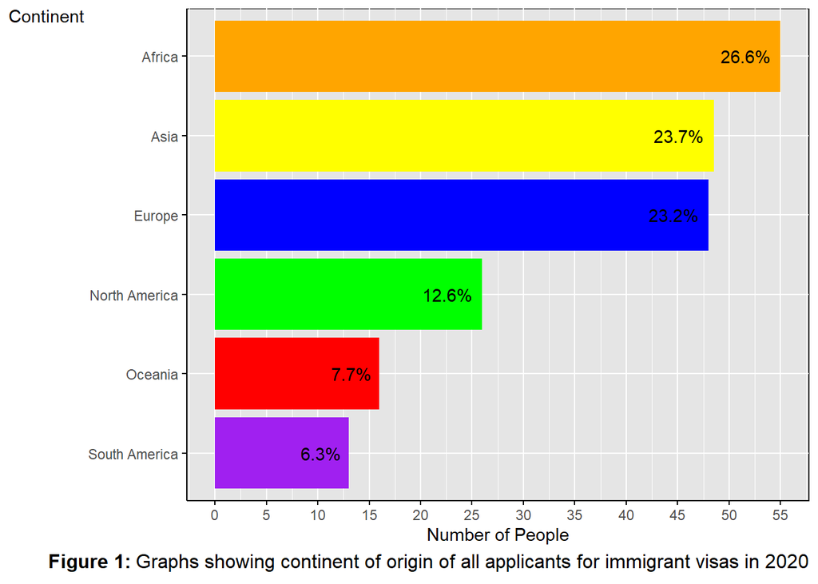

```r
library(ggplot2)
continent_data <- data.frame(
  Continent = c("Africa", "Asia", "Europe", "North America", "Oceania", "South America"),
  Number_of_People = c(55, 48.5, 48, 26, 16, 13),  # Use number of people
  Percentage = c(26.6, 23.7, 23.2, 12.6, 7.7, 6.3)  # Retain percentages for labels
)

# Plot the bar chart
ggplot(continent_data, aes(x = reorder(Continent, Number_of_People), y = Number_of_People, fill = Continent)) +
  geom_bar(stat = "identity") +
  geom_text(aes(label = paste0(Percentage, "%")),  hjust = 1.2) +  # Show percentage on the bars
  labs(x = "Continent", y = "Number of People",
  caption = expression(bold("Figure 1:")~"Graphs showing continent of origin of all applicants for immigrant visas in 2020")) +  # Bold "Figure 1" in caption
  scale_y_continuous(limits = c(0, 55), breaks = seq(0, 55, by = 5)) +  # Custom Y-axis with intervals of 5
  theme_minimal() +
  scale_fill_manual(values = c("Africa" = "orange", "Asia" = "yellow", "Europe" = "blue",
                               "North America" = "green", "Oceania" = "red", "South America" = "purple")) +
  coord_flip() +
  theme(panel.background = element_rect(fill = "grey90"),
        panel.border = element_blank(),
        panel.grid.major = element_line(color = "white"),
        panel.grid.minor = element_line(color = "white"),
        axis.line = element_line(color = "black"),  # Add black axis lines
        axis.ticks = element_line(color = "black"),  # Add black ticks on both axes
        axis.title.y = element_text(angle = 0),
        plot.caption = element_text(face = "italic", size = 12),
        legend.position = "none")# Rotate X-axis title
```

This graph displays the number of people from each continent who applied for immigrant visas in 2020. Africa has the highest number of applicants with 55 people, representing 26.6% of the total, followed by Asia (23.7%) and Europe (23.2%). North America, Oceania, and South America have significantly fewer applicants, with North America contributing 12.6%, Oceania 7.7%, and South America 6.3%. The percentages are displayed inside the bars, while the X-axis represents the number of people. The graph is clear, with colored bars representing each continent and no legend, as the colors are self-explanatory.